# Part V - Find Similar Themes with Reinert Textual Data Clustering

Rees W. Morrison

2022-02-04

Concluding this fifth post in a series of notes on Theme centrality and complexity, I turn to the Reinert textual clustering method. To invoke it, I removed portions of blog posts that are similar to all posts, as well as blogdown header material, and then combined all the posts for a Theme into a single “text.” Accordingly, 24 texts. Then I used R’s rainette package to perform Reinert textual clustering of those 24 texts.

Here are some characteristics of the method:

- it uses a **singular value decomposition** (SVD) of the **document-term matrix** (DTM) created from the corpus (collection of all 24 texts) [more on those two methods in later posts]
- it assigns each text (Theme) to only one cluster
- it is better suited for small “homogeneous” documents

The Reinert algorithm carries out divisive hierarchical clustering (as distinct from Part IV’s agglomerative clustering) with the goal to maximise the inter-cluster **Chi-squared distance** between clustered texts. The algorithm works its magic on the DTM, which only stores 1’s or 0’s (to show the presence or absence of terms in a text), not the frequencies of terms.

The algorithm splits the DTM into two clusters by maximizing the Chi-squared distance between them. To do so, it carries out the following steps:

- first, Themes are ordered according to their coordinates on the first axis of the **correspondence analysis** (CA) of the binary TDM (see [DisplayR](https://www.displayr.com/how-correspondence-analysis-works/) for a clear explanation of CA;
- next, Themes are grouped in two clusters based on this order, and the grouping with the maximum inter-cluster **Chi-squared distance** is kept;
- based on this grouping, each Theme is assigned in turn to the other cluster. If the new assignment gives a higher inter-cluster Chi-squared value, the Theme is kept in the other cluster. The operation is repeated until no new assignment gives a higher Chi-squared value;
- on the resulting clusters’ binary matrices, features are selected based on their frequency and on a contingency coefficient minimum value[^1]; and
- the largest of the two resulting clusters is then split with the same algorithm.

According to the calculations of the rainette package, the strongest associations (the highest Chi-squared values) are between Night and Sleep (almost 1100, in Cluster 4). The next time we use the Reinert text clustering method we will standardize (lemmatize) the Theme variants, such as converting “dancing” to “dance” and adjust plurals, such as “soldiers” to “soldier.”

The plot below displays the maximum of nine clusters that the algorithm can handle. The length of the bars visible behind the 10 terms that most represent a cluster correspond to the Chi-squared value. The “n =” row tells how many Themes comprise that cluster. The small dendrogram atop the cluster table visualizes the divisive, top-down methodology.

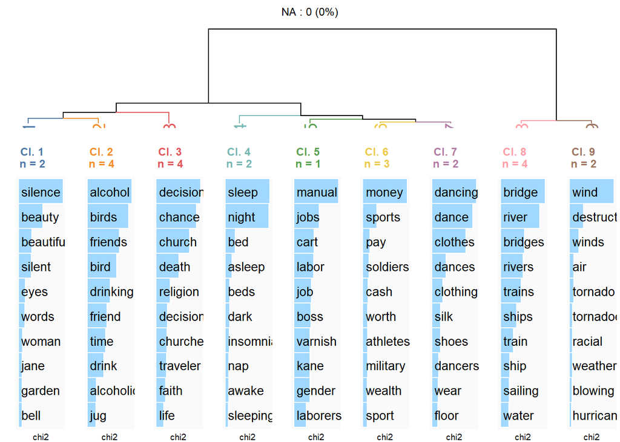

In a different vizualization of the same clustering outcome, this plot presents a “wordcloud” style, where the size of the word matches its relative Chi-squared value to the cluster.

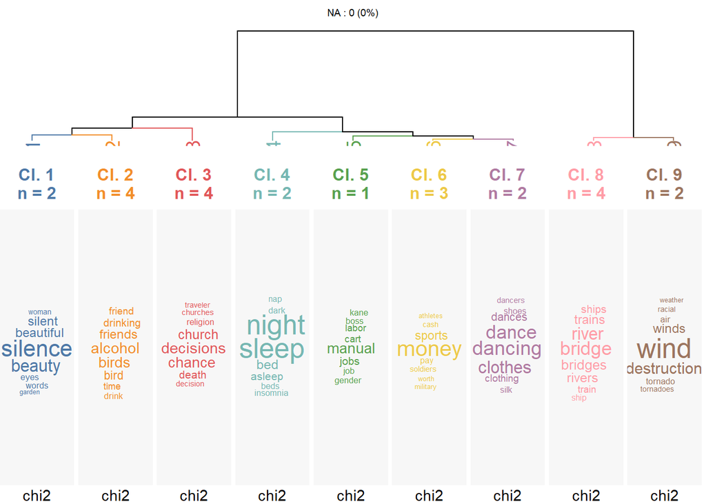

### Combine the pairings from the three clustering methods

Once the closest-pair are produced from k-means clustering, agglomerative hierarchical clustering, and Reinert text clustering, I combined them into a dataframe so that we can find out whether any Theme is closest to any other Theme more than once (or even three times).

Close Themes

| Theme | Two | One | Theme | One |
| --- | --- | --- | --- | --- |
| birds | A | 5 | money | 7 |
| chance | A | 4 | alcohol | 5 |
| bridges | B | 4 | beauty | 5 |
| rivers | B, F | 2 | decisions | 5 |
| death | C | 5 | friends | 5 |
| churches | C | 4 | soldiers | 5 |
| dancing | D | 4 | clothes | 4 |
| wind | D | 3 | nights | 4 |
| destruction | E | 2 | silence | 4 |
| sailing | E | 2 | sports | 4 |
| sleep | F | 2 | trains | 4 |
| work | G | 2 |  |  |
| time | G | 1 |  |  |

## Upcoming Post Series

Once the blog Themes from Art reaches 30 Themes (early February 2022), incorporates new metrics (e.g., newspaper references and Bing searches), drops the most dubious metrics (college majors and readability), and reconsiders the rank metrics (OED Bands and Top 1000 Words), the second series of five posts is likely to address:

*Part VI: Further Observations on Themes and Metrics

*Part VII: Cosine Similarity of Themes

*Part VIII: Latent Dirichelet Allocation (LDA)

*Part IX: Embeddings and Transformations

*Part X: Including Results of Above Algorithms into Theme Pairs Analysis

Around April 2022, a third series of five posts may encompass 36 Themes, a further modified set of metrics, and the following topics:

*Part XI: Critique of Quantifying Centrality and Complexity

*Part XII: Principal Components Analysis (PCA)

*Part XIII: Latent Semantic Analysis (LSA) or Uniform Manifold Approximation of Proportion (UMAP)

*Part XIV: Correspondence Analysis (CA)

*Part XV: Further Extensions of Theme Pairs and Analysis

A fourth series of posts, in the early Summer of 2022, may incorporate as many as 40 Themes. Among its potential topics, we envision:

*Part XVI: More Clustering Techniques

*Part XVII: Metaclustering, Validation tests, Assumptions of the Models

*Part XVIII: Structural Topic Models (STM)

*Part XIX: Other Tools for Analyzing Relationships between Themes

*Part XX: Applications of Theme-Pair Findings to Centrality and Complexity

[^1]: A measure of association based on chi-square. The value ranges between 0 and 1, with 0 indicating no association between the text (row) and term (column) variables and values close to 1 indicating a high degree of association between the variables.